# Parte 2 — Desenho, reamostragem e preparação

- Mostrar o código
- Esconder o código
- Ver o código fonte

Tutorial completo do sciModelFlowR (versão 1.0.2)

Autor

Walter Esfrain Pereira

Data de Publicação

19 de setembro de 2026

# 1 Por que a reamostragem decide o resultado

A pergunta científica é sempre “como este modelo se comporta em observações novas?”. A resposta depende inteiramente de **o que conta como observação nova**. Se talhões da mesma fazenda aparecem no treino e no teste, o modelo memoriza a fazenda e a estimativa fica otimista. Se o pré-processamento é ajustado no conjunto inteiro antes da divisão, a mediana do teste vaza para o treino. O `sciModelFlowR` trata a reamostragem como parte do **desenho**: `smf_design_spec()` declara grupos, blocos, tempo e coordenadas, e o pacote recusa esquemas incompatíveis em vez de avisar.

# 2 Esquemas de reamostragem

Cada conjunto simulado tem uma estrutura que pede um esquema próprio. A tabela mostra o que foi declarado e o que foi construído.

**Mostrar o código**

```r
campo <- ler("field_yield")
fazendas <- ler("farm_groups")
clima <- ler("climate_series")
solo <- ler("soil_spatial")

h <- smf_holdout_split(campo, train_prop = 0.7, id_column = "plot_id", seed = 101L)
v <- smf_vfold_cv(campo, v = 5L, id_column = "plot_id", seed = 102L)
gv <- smf_group_vfold_cv(fazendas, groups = "farm", v = 6L, id_column = "plot_id", seed = 103L)
tc <- smf_time_cv(clima, time = "day", initial = 400L, assess = 100L, id_column = "day", seed = 104L)
sc <- smf_spatial_cv(solo, coords = c("x", "y"), v = 4L, id_column = "point_id", seed = 105L)

resumo_esq <- data.frame(
  esquema = c("holdout (70/30)", "v-fold (v = 5)", "group v-fold (fazenda)",
              "time series CV", "spatial CV"),
  particoes = c(1L, length(v@splits), length(gv@splits), length(tc@splits), length(sc@splits)),
  propriedade = c("uma divisão aleatória estratificável",
                  "cada unidade no teste exatamente uma vez",
                  "fazendas inteiras fora do treino",
                  "passado treina, futuro testa",
                  "blocos espaciais inteiros fora do treino")
)
tab_smf(resumo_esq, caption = "Esquemas de reamostragem construídos para cada estrutura de dados.")
```

Esquemas de reamostragem construídos para cada estrutura de dados.

| esquema | particoes | propriedade |
| --- | --- | --- |
| holdout (70/30) | 1 | uma divisão aleatória estratificável |
| v-fold (v = 5) | 5 | cada unidade no teste exatamente uma vez |
| group v-fold (fazenda) | 6 | fazendas inteiras fora do treino |
| time series CV | 3 | passado treina, futuro testa |
| spatial CV | 4 | blocos espaciais inteiros fora do treino |

**Mostrar o código**

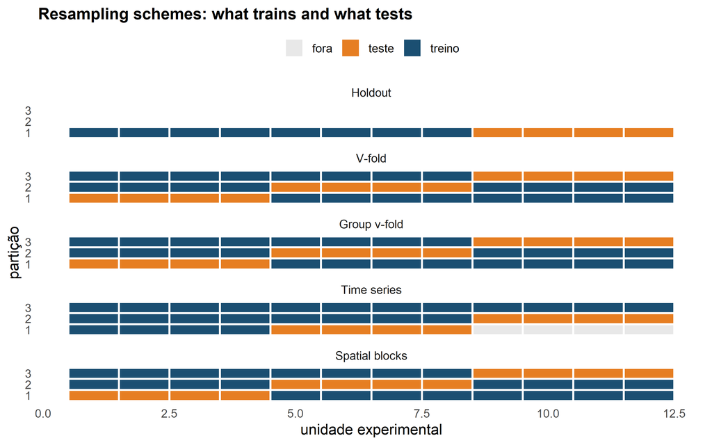

Figura 1: Como cada esquema parte os dados: treino em azul, teste em laranja. O esquema errado coloca vizinhos dos dois lados da fronteira.

```r
unidades <- 1:12
bloco <- function(nome, folds, papel_de) {
  do.call(rbind, lapply(folds, function(f) data.frame(
    scheme = nome, unit = unidades, fold = f, papel = papel_de(f)
  )))
}
esquema <- rbind(
  bloco("Holdout", 1L, function(f) ifelse(unidades <= 8, "treino", "teste")),
  bloco("V-fold", 1:3, function(f) ifelse(ceiling(unidades / 4) == f, "teste", "treino")),
  bloco("Group v-fold", 1:3, function(f) ifelse(ceiling(unidades / 4) == f, "teste", "treino")),
  bloco("Time series", 1:3, function(f) ifelse(unidades > 4 * f & unidades <= 4 * (f + 1),
                                               "teste", ifelse(unidades <= 4 * f, "treino", "fora"))),
  bloco("Spatial blocks", 1:3, function(f) ifelse(ceiling(unidades / 4) == f, "teste", "treino"))
)
esquema$scheme <- factor(esquema$scheme, levels = c("Holdout", "V-fold", "Group v-fold",
                                                    "Time series", "Spatial blocks"))
ggplot(esquema, aes(unit, factor(fold), fill = papel)) +
  geom_tile(colour = "white", linewidth = .8) +
  facet_wrap(~scheme, ncol = 1) +
  scale_fill_manual(values = c(treino = cores_smf[["primaria"]],
                               teste = cores_smf[["destaque"]],
                               fora = "#e8e8e8")) +
  labs(x = "unidade experimental", y = "partição", fill = NULL,
       title = "Resampling schemes: what trains and what tests") +
  theme(legend.position = "top", panel.grid = element_blank())
```

**NotaInterpretação**

No v-fold comum, vizinhos de uma mesma fazenda (ou de um mesmo bloco espacial) aparecem dos dois lados da fronteira. Nos esquemas `group`, `time series` e `spatial`, a fronteira respeita a dependência: a fazenda inteira sai, o futuro não treina o passado, o bloco espacial inteiro é retirado. A escolha do esquema **é** uma decisão científica — e precisa ser declarada.

# 3 O preço do vazamento, medido

A melhor forma de aprender é ver o erro acontecer. O pacote **recusa** o v-fold comum quando há grupos declarados:

**Mostrar o código**

```r
spec_iid <- smf_experiment_spec(
  task = smf_task_spec("regression", "yield"),
  data = smf_data_spec("yield", c("nitrogen", "farm"), id_column = "plot_id",
                       categorical = "farm"),
  design = smf_design_spec(id_column = "plot_id", group_columns = "farm"),
  preprocessing = smf_preprocess_spec("median", center = TRUE, scale = TRUE),
  resampling = smf_resampling_spec("kfold", n_splits = 6L, seed = 11L),
  model = smf_model_spec("linear_regression", "stats"),
  metrics = list(smf_metric_spec("rmse")),
  reproducibility = smf_reproducibility_spec(11L)
)
recusa_vaz <- tryCatch(smf_resample_experiment(spec_iid, fazendas),
                       error = function(e) conditionMessage(e))
cat(recusa_vaz, "\n")
```

```
Row-wise random resampling is incompatible with declared grouped/repeated units by default.
```

Para **quantificar** o otimismo, forçamos o mesmo esquema com `override = TRUE` e comparamos com o esquema correto. O modelo inclui a fazenda como preditor: com v-fold comum, o modelo aprende o efeito de cada fazenda nos outros talhões e acerta o teste; com `group`, a fazenda de teste é inédita.

**Mostrar o código**

```r
spec_grp <- smf_experiment_spec(
  task = smf_task_spec("regression", "yield"),
  data = smf_data_spec("yield", c("nitrogen", "farm"), id_column = "plot_id",
                       categorical = "farm"),
  design = smf_design_spec(id_column = "plot_id", group_columns = "farm"),
  preprocessing = smf_preprocess_spec("median", center = TRUE, scale = TRUE),
  resampling = smf_resampling_spec("group", n_splits = 6L, seed = 11L),
  model = smf_model_spec("linear_regression", "stats"),
  metrics = list(smf_metric_spec("rmse")),
  reproducibility = smf_reproducibility_spec(11L)
)
res_iid <- smf_resample_experiment(spec_iid, fazendas, override = TRUE)
res_grp <- smf_resample_experiment(spec_grp, fazendas)
rmse_iid <- res_iid@aggregate$mean[res_iid@aggregate$metric == "rmse"]
rmse_grp <- res_grp@aggregate$mean[res_grp@aggregate$metric == "rmse"]
```

**Mostrar o código**

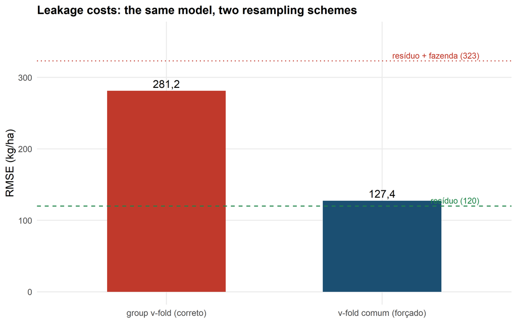

Figura 2: O mesmo modelo, dois esquemas: o v-fold comum (forçado) devolve RMSE muito menor que o group v-fold. As linhas marcam a verdade simulada.

```r
dados_vaz <- data.frame(
  esquema = c("v-fold comum (forçado)", "group v-fold (correto)"),
  rmse = c(rmse_iid, rmse_grp)
)
ggplot(dados_vaz, aes(esquema, rmse, fill = esquema)) +
  geom_col(width = .55, show.legend = FALSE) +
  geom_hline(yintercept = verdade$farm_groups$residual_sd, linetype = "dashed",
             colour = cores_smf[["sucesso"]]) +
  geom_hline(yintercept = sqrt(verdade$farm_groups$residual_sd^2 +
                               verdade$farm_groups$farm_sd^2),
             linetype = "dotted", colour = cores_smf[["alerta"]]) +
  geom_text(aes(label = fmt(rmse, 1)), vjust = -0.4) +
  scale_fill_manual(values = c(cores_smf[["alerta"]], cores_smf[["primaria"]])) +
  annotate("text", x = 2.45, y = verdade$farm_groups$residual_sd, hjust = 1, vjust = -0.4,
           label = "resíduo (120)", colour = cores_smf[["sucesso"]], size = 3.2) +
  annotate("text", x = 2.45, y = sqrt(verdade$farm_groups$residual_sd^2 +
           verdade$farm_groups$farm_sd^2), hjust = 1, vjust = -0.4,
           label = "resíduo + fazenda (323)", colour = cores_smf[["alerta"]], size = 3.2) +
  labs(x = NULL, y = "RMSE (kg/ha)",
       title = "Leakage costs: the same model, two resampling schemes") +
  ylim(0, 360)
```

**ImportanteInterpretação**

# 4 Bootstrap: a unidade certa muda o intervalo

O bootstrap responde “quanto esta estimativa varia se o experimento fosse repetido?”. A resposta só é honesta se a reamostragem respeitar a unidade que varia entre repetições. No ensaio com fazendas, a unidade é a **fazenda**, não o talhão.

**Mostrar o código**

```r
b_case <- tryCatch(
  smf_bootstrap(fazendas, smf_bootstrap_spec("case", n_resamples = 99L,
                                             interval = "percentile", seed = 7L),
                statistic = function(z) c(media = mean(z$yield)),
                design = smf_design_spec(id_column = "plot_id",
                                         group_columns = "farm")),
  error = function(e) conditionMessage(e))
b_bca_cl <- tryCatch(
  smf_bootstrap(fazendas, smf_bootstrap_spec("cluster", n_resamples = 99L,
                                             sampling_unit = "farm",
                                             interval = "bca", seed = 7L),
                statistic = function(z) c(media = mean(z$yield)),
                design = smf_design_spec(id_column = "plot_id",
                                         group_columns = "farm")),
  error = function(e) conditionMessage(e))
cat("case (iid):", b_case, "\n\n")
```

```
case (iid): The requested bootstrap unit does not preserve dependence declared in DesignSpec.
```

**Mostrar o código**

```r
cat("BCa com cluster:", b_bca_cl, "\n")
```

```
BCa com cluster: The generic row-delete BCa implementation is available only for case bootstrap; other dependence-aware schemes require a scheme-specific jackknife and are blocked rather than approximated.
```

**Mostrar o código**

```r
b_cl <- smf_bootstrap(fazendas,
  smf_bootstrap_spec("cluster", n_resamples = 1999L, sampling_unit = "farm",
                     interval = "percentile", seed = 7L),
  statistic = function(z) c(media = mean(z$yield)),
  design = smf_design_spec(id_column = "plot_id", group_columns = "farm"))
ci_cl <- smf_bootstrap_interval(b_cl)
estab <- smf_bootstrap_stability(b_cl)
```

**Mostrar o código**

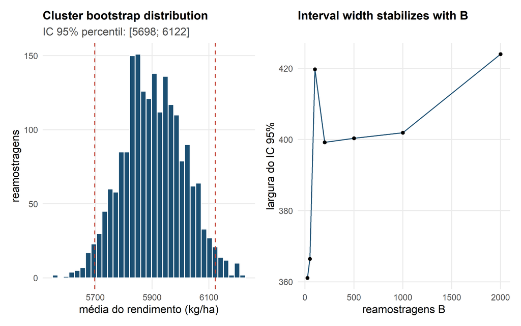

```r
p1 <- ggplot(data.frame(media = b_cl@estimates[[1]]), aes(media)) +
  geom_histogram(fill = cores_smf[["primaria"]], colour = "white", bins = 35) +
  geom_vline(xintercept = ci_cl["media", ], linetype = "dashed",
             colour = cores_smf[["alerta"]]) +
  labs(x = "média do rendimento (kg/ha)", y = "reamostragens",
       title = "Cluster bootstrap distribution",
       subtitle = paste0("IC 95% percentil: [", fmt(ci_cl["media", 1], 0),
                         "; ", fmt(ci_cl["media", 2], 0), "]"))
p2 <- ggplot(subset(estab, statistic == "media"), aes(B, width)) +
  geom_line(colour = cores_smf[["primaria"]]) +
  geom_point(size = 1.4) +
  labs(x = "reamostragens B", y = "largura do IC 95%",
       title = "Interval width stabilizes with B")
patchwork::wrap_plots(p1, p2)
```

**AvisoArmadilha**

O bootstrap `case` (talhão a talhão) foi **recusado** porque subestimaria a variabilidade: talhões da mesma fazenda não são repetições independentes. O BCa com cluster também foi recusado — a correção de viés exigiria um jackknife específico do esquema, e o pacote prefere bloquear a aproximar. Os dois bloqueios são a mesma filosofia: **melhor um erro explícito do que um número plausível e errado**.

# 5 Preparação: imputação, centro e escala

A Parte 1 mostrou dois tipos de ausência: MCAR no nitrogênio e MAR (bloco B4) na matéria orgânica. Antes de comparar estratégias de imputação, porém, um passo obrigatório: **os outliers**. A tabela abaixo mostra o coeficiente da matéria orgânica (verdade plantada: 120) em quatro cenários.

**Mostrar o código**

```r
sem_out <- campo[!campo$plot_id %in% verdade$field_yield$outlier_ids, ]
dspec <- smf_data_spec("yield", c("nitrogen", "water", "organic_matter"),
                       id_column = "plot_id")
coef_om <- function(dados, imp) {
  pp <- smf_fit_preprocessor(dados, smf_preprocess_spec(imp), dspec, role = "training")
  tr <- smf_apply_preprocessor(pp, dados)
  tr[["yield"]] <- dados[["yield"]]
  fit <- lm(yield ~ nitrogen + water + organic_matter, data = tr)
  c(slope = unname(coef(fit)[["organic_matter"]]),
    n = sum(stats::complete.cases(tr)))
}
c_com <- coef_om(campo, "none")
c_none <- coef_om(sem_out, "none")
c_mean <- coef_om(sem_out, "mean")
c_med <- coef_om(sem_out, "median")
tab_imp <- data.frame(
  cenario = c("todos os dados, sem imputação",
              "sem outliers, sem imputação (casos completos)",
              "sem outliers, imputação pela média",
              "sem outliers, imputação pela mediana"),
  coef_mo = c(c_com["slope"], c_none["slope"], c_mean["slope"], c_med["slope"]),
  linhas_usadas = c(c_com["n"], c_none["n"], c_mean["n"], c_med["n"])
)
tab_smf(tab_imp, caption = "Coeficiente da matéria orgânica sob diferentes decisões de tratamento de discrepâncias (verdade plantada: 120).")
```

Coeficiente da matéria orgânica sob diferentes decisões de tratamento de discrepâncias (verdade plantada: 120).

| cenario | coef_mo | linhas_usadas |
| --- | --- | --- |
| todos os dados, sem imputação | 285,808 | 153 |
| sem outliers, sem imputação (casos completos) | 115,286 | 149 |
| sem outliers, imputação pela média | 198,395 | 175 |
| sem outliers, imputação pela mediana | 206,427 | 175 |

**Mostrar o código**

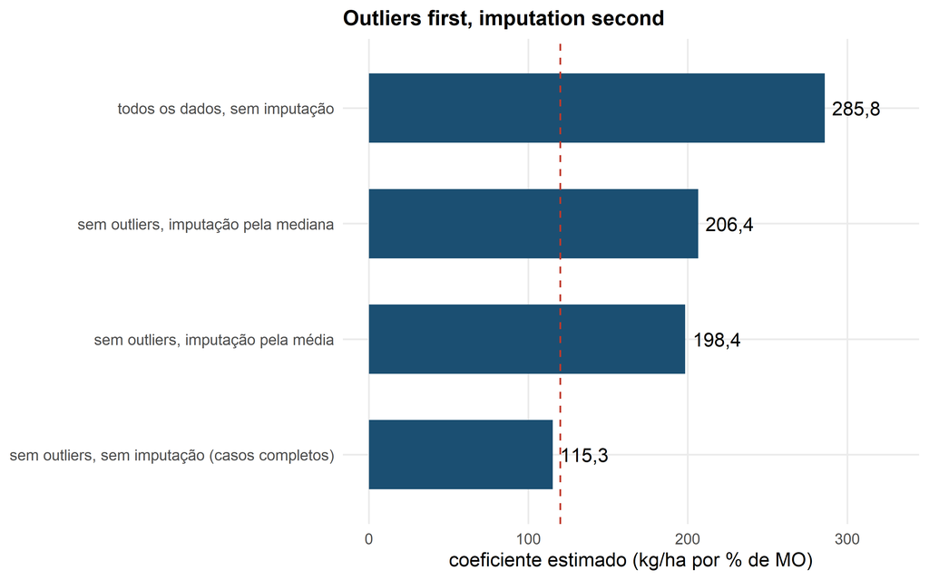

Figura 4: O coeficiente da matéria orgânica: os outliers dominam o erro; removidos, a escolha de imputação ainda desloca a estimativa.

```r
ggplot(tab_imp, aes(stats::reorder(cenario, coef_mo), coef_mo)) +
  geom_col(fill = cores_smf[["primaria"]], width = .6) +
  geom_hline(yintercept = verdade$field_yield$beta[["organic_matter"]],
             linetype = "dashed", colour = cores_smf[["alerta"]]) +
  geom_text(aes(label = fmt(coef_mo, 1)), hjust = -0.15) +
  coord_flip() +
  labs(x = NULL, y = "coeficiente estimado (kg/ha por % de MO)",
       title = "Outliers first, imputation second") +
  ylim(0, max(tab_imp$coef_mo) * 1.15)
```

**ImportanteInterpretação**

Três lições em uma tabela. (1) Com os cinco outliers dentro, o coeficiente quase triplica (286 contra a verdade 120) — discrepância numérica é o primeiro problema, não a ausência. (2) Removidos os outliers, casos completos recuperam 115,3, perto da verdade, mas usam apenas 149 das 180 parcelas. (3) A imputação pela média ou mediana usa todas as linhas, mas desloca o coeficiente para 198/206: imputar **não é neutro**. A decisão precisa ser declarada e testada em sensibilidade.

**Mostrar o código**

```r
coef_escala <- function(center, scale) {
  pp <- smf_fit_preprocessor(sem_out, smf_preprocess_spec("median", center = center,
                                                          scale = scale),
                             dspec, role = "training")
  tr <- smf_apply_preprocessor(pp, sem_out)
  tr[["yield"]] <- sem_out[["yield"]]
  fit <- lm(yield ~ nitrogen + water + organic_matter, data = tr)
  round(coef(fit)[-1], 3)
}
tab_escala <- rbind(
  "sem centro, sem escala" = coef_escala(FALSE, FALSE),
  "com centro" = coef_escala(TRUE, FALSE),
  "com centro e escala" = coef_escala(TRUE, TRUE)
)
tab_smf(as.data.frame(tab_escala), caption = "Efeito de centrar e escalar nos coeficientes: centrar não muda inclinações; escalar muda a unidade.")
```

Efeito de centrar e escalar nos coeficientes: centrar não muda inclinações; escalar muda a unidade.

|  | nitrogen | water | organic_matter |
| --- | --- | --- | --- |
| sem centro, sem escala | 24,004 | 2,744 | 206,427 |
| com centro | 24,004 | 2,744 | 206,427 |
| com centro e escala | 1044,576 | 302,382 | 91,741 |

**DicaBoa prática**

Centrar não altera inclinações (só desloca o intercepto). Escalar muda a unidade do coeficiente — e é indispensável para comparar a importância de preditores em escalas diferentes. O pacote ajusta o pré-processamento **dentro de cada fold**; nas Partes 3 e 4 isso será automático dentro de `smf_fit_experiment()` e `smf_resample_experiment()`.

# 6 Desbalanceamento: mexer só no treino

**Mostrar o código**

```r
doenca <- ler("disease_binary")
doenca$disease <- factor(doenca$disease, levels = c(0, 1))
```

No conjunto de doença, a classe positiva é 13,8% e o ruído de rótulo limita o teto. As estratégias de balanceamento reamostram **o treino**; o teste permanece intocado.

**Mostrar o código**

```r
tab_bal <- do.call(rbind, lapply(c("none", "downsample", "upsample", "smote"), function(m) {
  out <- tryCatch(smf_apply_imbalance(doenca, "disease", smf_imbalance_spec(m),
                                      context = "training", seed = 20260919),
                  error = function(e) conditionMessage(e))
  if (is.character(out)) {
    data.frame(metodo = m, classe_0 = NA_integer_, classe_1 = NA_integer_,
               observacao = out)
  } else {
    data.frame(metodo = m,
               classe_0 = sum(out@data$disease == "0"),
               classe_1 = sum(out@data$disease == "1"),
               observacao = "")
  }
}))
tab_smf(tab_bal, caption = "Contagens de classe antes e depois de cada estratégia de balanceamento (aplicada só ao treino).")
```

Contagens de classe antes e depois de cada estratégia de balanceamento (aplicada só ao treino).

| metodo | classe_0 | classe_1 | observacao |
| --- | --- | --- | --- |
| none | 345 | 55 |  |
| downsample | 55 | 55 |  |
| upsample | 345 | 345 |  |
| smote | NA | NA | Error in `step_smote()`: |

**Mostrar o código**

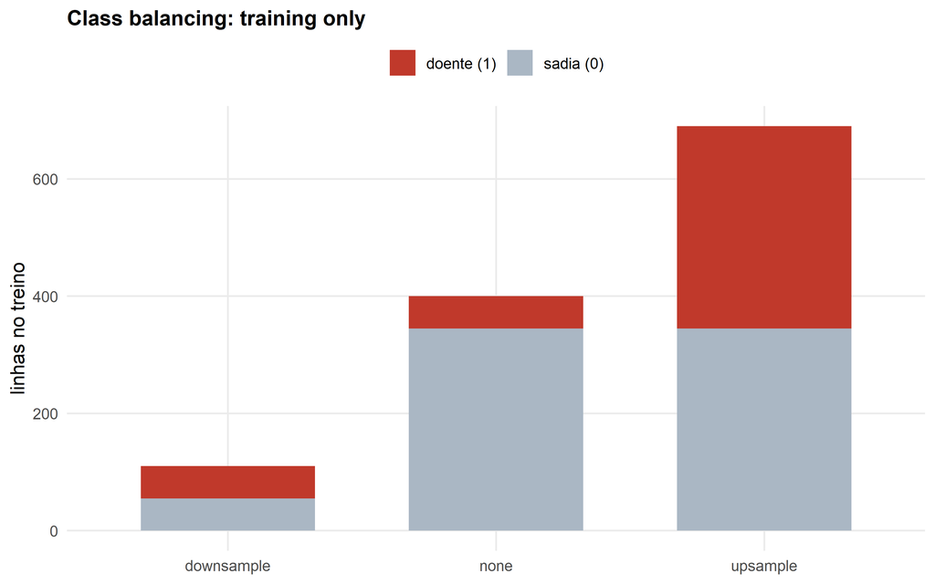

Figura 5: Balanceamento no treino: downsample iguala as classes reduzindo a maioria; upsample iguala replicando a minoria; o teste nunca é tocado.

```r
bal_longo <- data.frame(
  metodo = rep(tab_bal$metodo, 2),
  classe = rep(c("sadia (0)", "doente (1)"), each = nrow(tab_bal)),
  n = c(tab_bal$classe_0, tab_bal$classe_1)
)
ggplot(subset(bal_longo, !is.na(n)), aes(metodo, n, fill = classe)) +
  geom_col(width = .65) +
  scale_fill_manual(values = c("sadia (0)" = cores_smf[["claro"]],
                               "doente (1)" = cores_smf[["alerta"]])) +
  labs(x = NULL, y = "linhas no treino", fill = NULL,
       title = "Class balancing: training only") +
  theme(legend.position = "top")
```

**AvisoArmadilha**

# 7 Seleção de atributos e representação

Selecionar atributos com o conjunto inteiro é uma forma sutil de vazamento. O caminho correto é selecionar **dentro de cada fold**. O resultado traz as pontuações por fold e uma medida de estabilidade.

**Mostrar o código**

```r
cv_campo <- smf_vfold_cv(sem_out, v = 5L, id_column = "plot_id", seed = 9L)
sel <- smf_feature_select_resamples(
  sem_out, "yield", smf_feature_spec("mutual_information", n_features = 3L),
  cv_campo, id_column = "plot_id"
)
tab_sel <- merge(sel@scores, sel@stability, by = "feature", all = TRUE)
tab_smf(tab_sel, caption = "Seleção por informação mútua (3 atributos por fold) repetida em 5 folds: frequência de seleção e estabilidade por atributo.")
```

Seleção por informação mútua (3 atributos por fold) repetida em 5 folds: frequência de seleção e estabilidade por atributo.

| feature | selection_frequency | frequency |
| --- | --- | --- |
| block | 0,0 | 0,0 |
| genotype | 0,0 | 0,0 |
| nitrogen | 1,0 | 1,0 |
| organic_matter | 0,6 | 0,6 |
| potassium | 0,6 | 0,6 |
| water | 0,8 | 0,8 |

**Mostrar o código**

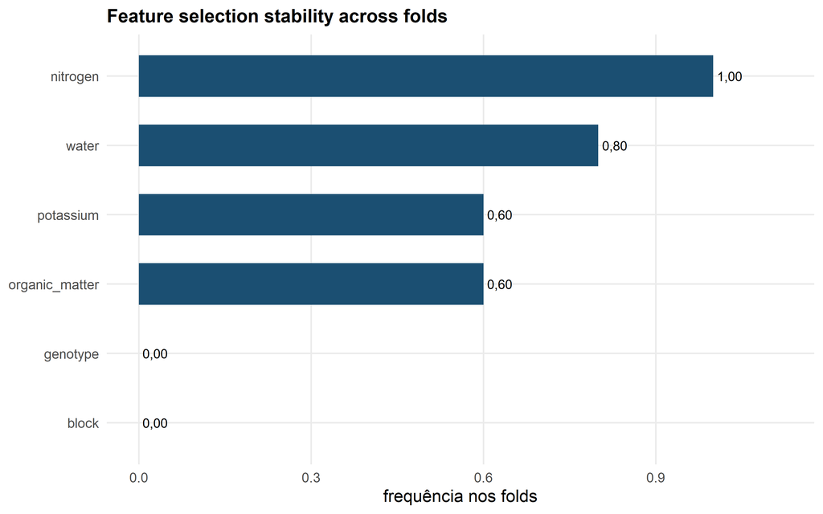

Figura 6: Estabilidade da seleção entre folds: atributos escolhidos em todos os folds são os candidatos confiáveis.

```r
estab_sel <- sel@stability
names(estab_sel)[2] <- "frequencia"
ggplot(estab_sel, aes(stats::reorder(feature, frequencia), frequencia)) +
  geom_col(fill = cores_smf[["primaria"]], width = .6) +
  geom_text(aes(label = fmt(frequencia, 2)), hjust = -0.15, size = 3.2) +
  coord_flip() +
  labs(x = NULL, y = "frequência nos folds",
       title = "Feature selection stability across folds") +
  ylim(0, 1.12)
```

Em alta dimensão (200 comprimentos de onda para 120 amostras), a solução é **representação**: PCA ou PLS reduzem a dimensão antes do modelo, sempre ajustadas no treino. O experimento abaixo usa a representação PCA declarada na especificação.

**Mostrar o código**

```r
espectro <- ler("spectral_pn")
ondas <- grep("^w", names(espectro), value = TRUE)
fazer_rep <- function(k) {
  spec <- smf_experiment_spec(
    task = smf_task_spec("regression", "protein"),
    data = smf_data_spec("protein", ondas, id_column = "sample_id"),
    design = smf_design_spec(id_column = "sample_id"),
    features = smf_feature_spec("pca", n_features = k, representation = "pca"),
    resampling = smf_resampling_spec("holdout", train_prop = 0.75, seed = 4L),
    model = smf_model_spec("linear_regression", "stats"),
    metrics = list(smf_metric_spec("rmse")),
    reproducibility = smf_reproducibility_spec(4L)
  )
  smf_fit_experiment(spec, espectro)
}
fit_rep <- fazer_rep(8L)
var_exp <- cumsum(fit_rep@fit@features@state$sdev^2) /
  sum(fit_rep@fit@features@state$sdev^2)
tab_smf(data.frame(componente = seq_along(var_exp),
                   var_acumulada = var_exp),
        caption = "Variância acumulada dos componentes principais ajustados no treino.")
```

Variância acumulada dos componentes principais ajustados no treino.

| componente | var_acumulada |
| --- | --- |
| 1 | 0,468 |
| 2 | 0,756 |
| 3 | 0,992 |
| 4 | 0,993 |
| 5 | 0,993 |
| 6 | 0,993 |
| 7 | 0,994 |
| 8 | 0,994 |
| 9 | 0,994 |
| 10 | 0,994 |
| 11 | 0,995 |
| 12 | 0,995 |
| 13 | 0,995 |
| 14 | 0,995 |
| 15 | 0,995 |
| 16 | 0,996 |
| 17 | 0,996 |
| 18 | 0,996 |
| 19 | 0,996 |
| 20 | 0,996 |
| 21 | 0,996 |
| 22 | 0,997 |
| 23 | 0,997 |
| 24 | 0,997 |
| 25 | 0,997 |
| 26 | 0,997 |
| 27 | 0,997 |
| 28 | 0,997 |
| 29 | 0,998 |
| 30 | 0,998 |

[output cut: 60 more lines]

**Mostrar o código**

```r
rmse_comp <- do.call(rbind, lapply(c(2L, 4L, 6L, 8L, 12L, 20L), function(k) {
  f <- fazer_rep(k)
  data.frame(componentes = k,
             rmse = f@metrics$value[f@metrics$metric == "rmse"])
}))
tab_smf(rmse_comp, caption = "RMSE de validação por número de componentes principais (ruído verdadeiro: 0,25).")
```

RMSE de validação por número de componentes principais (ruído verdadeiro: 0,25).

| componentes | rmse |
| --- | --- |
| 2 | 0,946 |
| 4 | 0,306 |
| 6 | 0,307 |
| 8 | 0,307 |
| 12 | 0,302 |
| 20 | 0,331 |

**Mostrar o código**

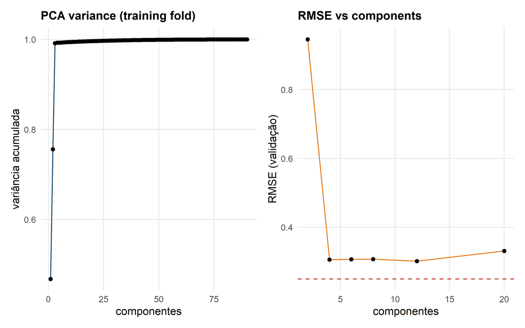

Figura 7: Representação por PCA: variância acumulada (esquerda) e RMSE de validação por número de componentes (direita).

```r
p_var <- ggplot(data.frame(componente = seq_along(var_exp), var = var_exp),
                aes(componente, var)) +
  geom_line(colour = cores_smf[["primaria"]]) +
  geom_point(size = 1.6) +
  labs(x = "componentes", y = "variância acumulada",
       title = "PCA variance (training fold)")
p_rmse <- ggplot(rmse_comp, aes(componentes, rmse)) +
  geom_line(colour = cores_smf[["destaque"]]) +
  geom_point(size = 1.6) +
  geom_hline(yintercept = 0.25, linetype = "dashed", colour = cores_smf[["alerta"]]) +
  labs(x = "componentes", y = "RMSE (validação)",
       title = "RMSE vs components")
patchwork::wrap_plots(p_var, p_rmse)
```

**NotaInterpretação**

# 8 Exercícios da Parte 2

**NotaExercício 2.1 — Prove o vazamento**

No v-fold comum sobre `farm_groups` (com `override = TRUE`), conte quantas fazendas aparecem nos dois lados de cada fold. Depois repita com o `group v-fold` e mostre que a contagem é zero. (Dica: `s@train_index`, `s@test_index` e `fazendas$farm`.)

**NotaExercício 2.2 — Verifique a ordem temporal**

No `smf_time_cv()` sobre `climate_series`, confirme que em **todos** os folds o dia de teste é posterior ao último dia de treino. Depois refaça com `smf_vfold_cv()` e mostre um caso em que a ordem é violada.

**NotaExercício 2.3 — Quando o vazamento desaparece?**

Repita a comparação v-fold × group v-fold **sem** a coluna `farm` nos preditores. O otimismo continua? Explique por quê, e o que isso ensina sobre quando o esquema errado é inofensivo (e por que ainda assim é arriscado).

**NotaExercício 2.4 — MCAR contra MAR na imputação**

Compare o coeficiente do nitrogênio (MCAR) e o da matéria orgânica (MAR) nas três estratégias de imputação. Qual dos dois coeficientes é mais sensível? Relacione com o padrão de ausência visto na Parte 1.

**CuidadoSoluções**

**2.1.** Com v-fold comum forçado, cada fold tem talhões de fazendas que também estão no treino (sobreposição > 0 em todos os folds). No `group v-fold`, a interseção de fazendas treino ∩ teste é zero por construção.

**2.2.** No `smf_time_cv()`, `max(train) < min(test)` em todos os folds (expansão para o futuro). No `smf_vfold_cv()`, como a divisão é aleatória, algum fold terá dia de teste anterior a dias de treino — o modelo “aprende o futuro”.

**2.3.** Sem `farm` nos preditores, o modelo não consegue memorizar o efeito de fazenda: o otimismo praticamente desaparece. Mas continua arriscado: basta que exista **algum** atributo que carregue informação da fazenda (solo, clima local, prática de manejo) para o vazamento voltar. O desenho certo não depende de o modelo “não conseguir” explorar o vazamento.

**2.4.** O coeficiente da matéria orgânica (MAR, dependente do bloco) é mais sensível: as ausências concentram-se no B4, e imputar pela média global ignora essa estrutura. O nitrogênio (MCAR) sofre menos. O diagnóstico da Parte 1 (ausência por bloco) já previa isso.